# Data Mining Coursework

### 2.3.1 3D plotting - various principal components

Visualising the first 3 principal components.

```r
plot3d(Water.Clustering$PC1, Water.Clustering$PC2, Water.Clustering$PC3, col=km$cluster)
```

Image Capture is shown below.Most of the clusters are tightly defined with the yellow and brown clusters closest together. There are a few outliers seen as well.

[figure not shown]

Image Capture of 3D cluster of PC1,PC2,PC3

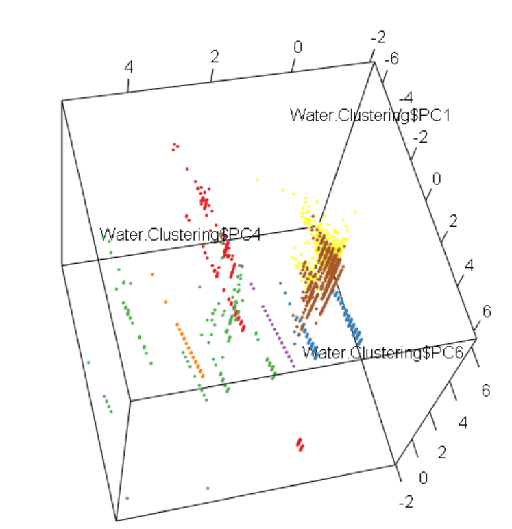

Image Capture of 3D clusters containing determinandC associated with pollutants

```r
plot3d(Water.Clustering$PC1, Water.Clustering$PC4, Water.Clustering$PC6, col=km$cluster) # 4 and 6 has only determinanC pollutants.
```

This plot is more clearly defined.

## 2.4 Cluster sizes - sort clusters by size

```r
sort(table(km$cluster))
```

```
##
##    3    1    6    5    7    4    2
##  251  308  423  715 1007 1379 1533
```

```r
clust <- names(sort(table(km$cluster)))
clust
```

```
## [1] "3" "1" "6" "5" "7" "4" "2"
```

## 2.5 Getting the instances in each cluster

```r
Cluster1 <-(Water[km$clust == clust[1], ])
#Cluster1    # Viewing contents of Cluster 1

Cluster2 <-(Water[km$clust == clust[2], ])
Cluster3 <-(Water[km$clust == clust[3], ])
Cluster4 <-(Water[km$clust == clust[4], ])
Cluster5 <-(Water[km$clust == clust[5], ])
Cluster6 <-(Water[km$clust == clust[6], ])
Cluster7 <-(Water[km$clust == clust[7], ])
Cluster8 <-(Water[km$clust == clust[8], ])
Cluster9 <-(Water[km$clust == clust[9], ])
```

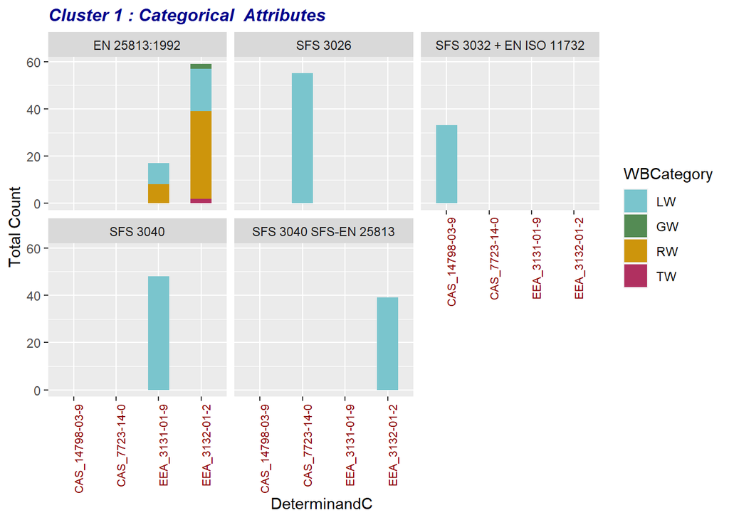

```r
# setting custom color scale for use as 'WBCategory' colors

custom.palette <- c(
  "LW" = "cadetblue3",
  "GW" = "palegreen4",
  "RW" = "darkgoldenrod3",
  "TW" = "maroon"
)

# plot the 7 cluster with erence to determinandC, WBCategory and method


ggplot(Cluster1,aes(x = determinandC, fill = WBCategory)) + geom_bar(width = 0.5) + facet_wrap(~method) + ggtitle("Cluster 1 : Categorical  Attributes") + xlab("DeterminandC ") + ylab("Total Count") + theme(plot.title = element_text(color="dark blue", size=12, face="bold.italic"),axis.text.x = element_text(angle = 90, hjust = 1, size=8,color="darkred")) +     scale_fill_manual(
    values = custom.palette,
    limits = names(custom.palette)
  )
```

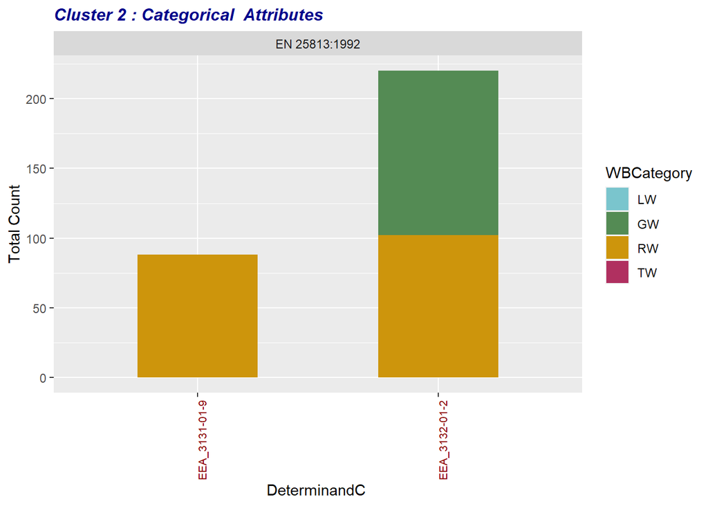

```r
ggplot(Cluster2,aes(x = determinandC, fill = WBCategory)) + geom_bar(width = 0.5) + facet_wrap(~method) + ggtitle("Cluster 2 : Categorical  Attributes") + xlab("DeterminandC ") + ylab("Total Count") + theme(plot.title = element_text(color="dark blue", size=12, face="bold.italic"), axis.text.x = element_text(angle = 90, hjust = 1, size=8,color="darkred"))+     scale_fill_manual(
    values = custom.palette,
    limits = names(custom.palette)
  )
```

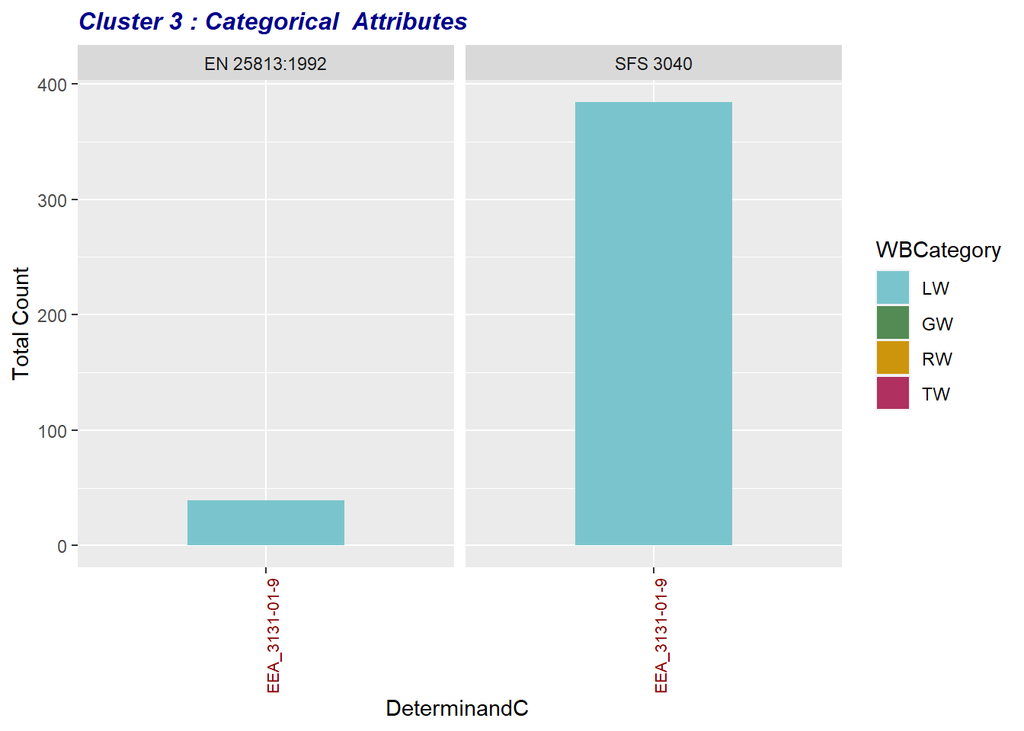

```r
ggplot(Cluster3,aes(x = determinandC, fill = WBCategory)) + geom_bar(width = 0.5) + facet_wrap(~method) + ggtitle("Cluster 3 : Categorical  Attributes") + xlab("DeterminandC ") + ylab("Total Count") + theme(plot.title = element_text(color="dark blue", size=12, face="bold.italic"), axis.text.x = element_text(angle = 90, hjust = 1, size=8,color="darkred"))+     scale_fill_manual(
    values = custom.palette,
    limits = names(custom.palette)
  )
```

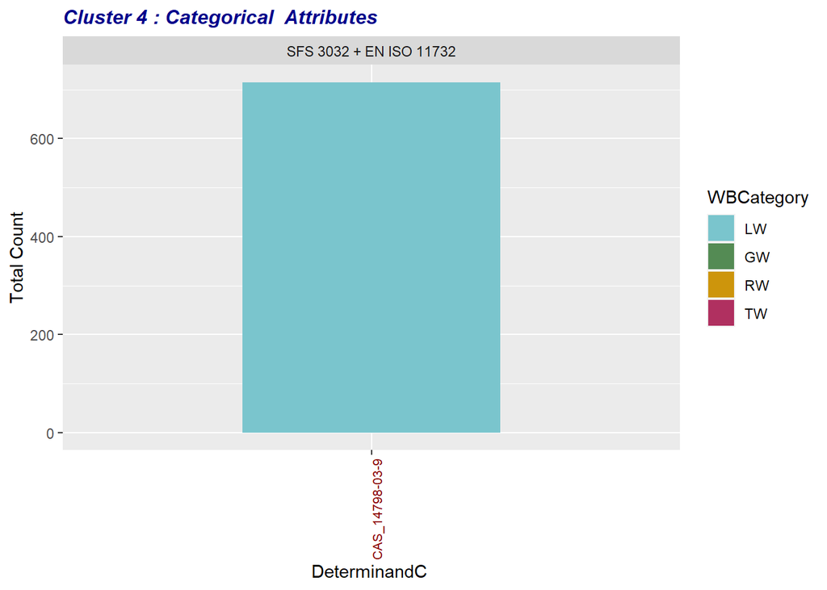

```r
ggplot(Cluster4,aes(x = determinandC, fill = WBCategory)) + geom_bar(width = 0.5) + facet_wrap(~method) + ggtitle("Cluster 4 : Categorical  Attributes") + xlab("DeterminandC ") + ylab("Total Count") + theme(plot.title = element_text(color="dark blue", size=12, face="bold.italic"), axis.text.x = element_text(angle = 90, hjust = 1, size=8,color="darkred"))+     scale_fill_manual(
    values = custom.palette,
    limits = names(custom.palette)
  )
```

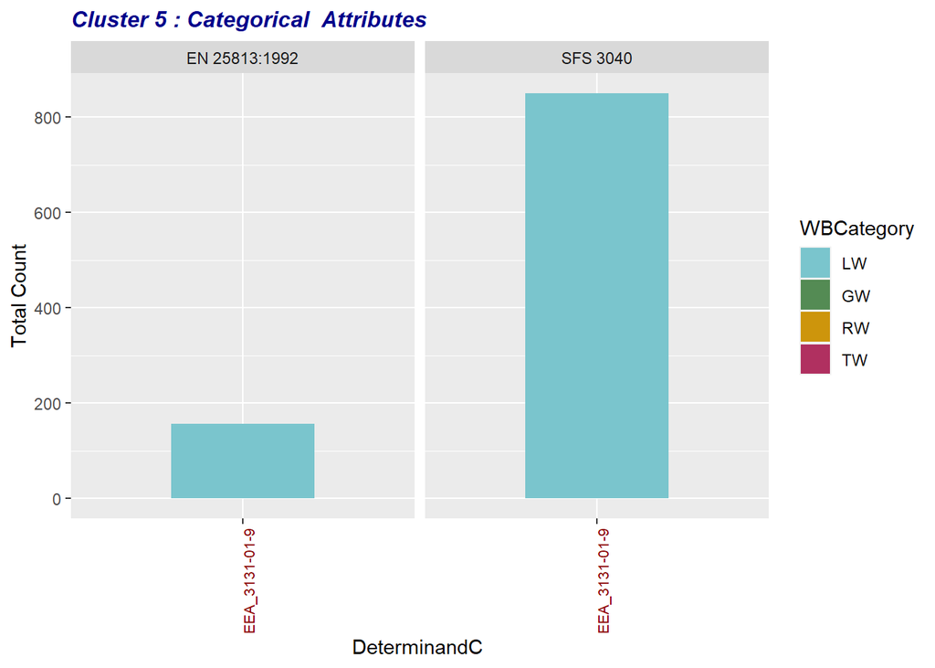

```r
ggplot(Cluster5,aes(x = determinandC, fill = WBCategory)) + geom_bar(width = 0.5) + facet_wrap(~method) + ggtitle("Cluster 5 : Categorical  Attributes") + xlab("DeterminandC ") + ylab("Total Count") + theme(plot.title = element_text(color="dark blue", size=12, face="bold.italic"), axis.text.x = element_text(angle = 90, hjust = 1, size=8,color="darkred"))+     scale_fill_manual(
    values = custom.palette,
    limits = names(custom.palette)
  )
```

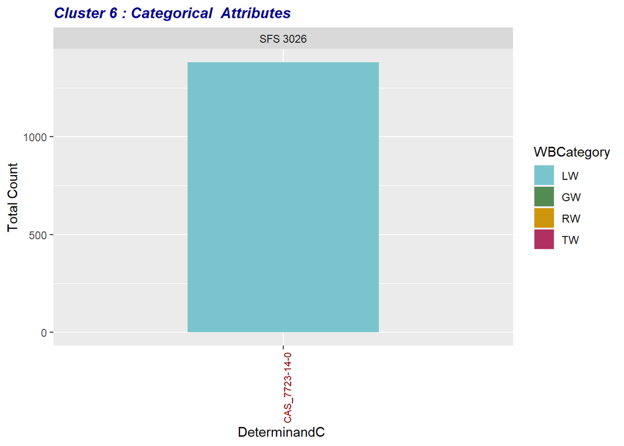

```r
ggplot(Cluster6,aes(x = determinandC,fill = WBCategory)) + geom_bar(width = 0.5) + facet_wrap(~method) + ggtitle("Cluster 6 : Categorical  Attributes") + xlab("DeterminandC ") + ylab("Total Count") + theme(plot.title = element_text(color="dark blue", size=12, face="bold.italic"), axis.text.x = element_text(angle = 90, hjust = 1, size=8,color="darkred"))+     scale_fill_manual(
    values = custom.palette,
    limits = names(custom.palette)
  )
```

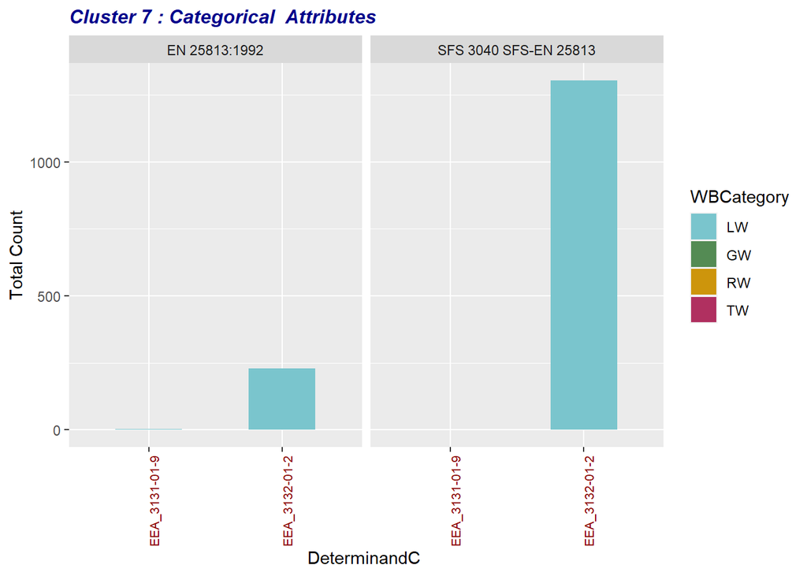

```r
ggplot(Cluster7,aes(x = determinandC,fill = WBCategory)) + geom_bar(width = 0.5) + facet_wrap(~method) + ggtitle("Cluster 7 : Categorical  Attributes")+ xlab("DeterminandC ") + ylab("Total Count") + theme(plot.title = element_text(color="dark blue", size=12, face="bold.italic"), axis.text.x = element_text(angle = 90, hjust = 1, size=8,color="darkred"))+     scale_fill_manual(
    values = custom.palette,
    limits = names(custom.palette)
  )
```

The ideal number of clusters has been found by evaluating the outputs of both Elbow and Silhouette methods. The elbow was not very clear at all. The highest point in silhouette was clearly 7 and hence it was chosen as the k value for k-means algorithm.K-means has been chosen because it is computationally low cost and is widely used. From the visualisation of the PCAs including the 3D plot, the data points have been grouped into distinct structures with a few outliers.There is some overlap between two clusters(the yellow and brown ones). The clusters sizes are varied as well (from 251 to 1533). From the plots above,the clusters are grouped by determinadC and WBcategory.Cluster 1 and 2 have GW and RW in it. TW, which has the least instances has been grouped into cluster 1 due to the presence of dissolved oxygen. The pollutants(phosphorous and Ammonium) are separated from the oxygen saturation and dissolved oxygen which can be seen clearly in clusters 3-7. When the clustering was run with TestWater(now edited out),separation had been achieved between GW and RW.Ideally , the clustering should be applied on all the three datasets combined.

# 3 Task 2b: Choose your own Data Mining activity

```r
#install.packages('naivebayes')
library(naivebayes)
library(e1071)
```

```r
##Training With Class
head(WaterNormalised,5)   # viewing the preprocessed normalised training dataset from earlier with category intact
```

```
##   siteIDScheme.eionetMonitoringSiteCode siteIDScheme.euMonitoringSiteCode
## 1                                     0                                 1
## 3                                     0                                 1
## 4                                     0                                 1
## 5                                     1                                 0
## 6                                     0                                 1
##   determinandC.CAS_14798-03-9 determinandC.CAS_7723-14-0
## 1                           0                          0
## 3                           0                          0
## 4                           0                          1
## 5                           0                          0
## 6                           0                          0
##   determinandC.EEA_3131-01-9 determinandC.EEA_3132-01-2   NSamples     minValue
## 1                          1                          0 0.16666667 3.433857e-01
## 3                          1                          0 0.04166667 6.909898e-01
```

[output cut: 21 more lines]

```r
#View(WaterNormalised)

# One hot Encoding the waterNormalised (normalised training set)

preproc2 <- preProcess(WaterNormalised[,-17], method = c("range"))
OHE.WaterNormWithClass <- predict(preproc2,WaterNormalised)
#View(OHE.WaterNormWithClass)
```

```r
# Preprocessing
 set.seed(123)

#Testing Set - With No Class
# creating a dataset identical to TestWater but without the class
TestWaterNoClass <- TestWater
TestWaterNoClass$WBCategory <- NULL
#View(TestWaterNoClass)

# One hot encoding the testing set
binaryVarsTestNoClass <- dummyVars( ~ ., data = TestWaterNoClass)
OHE.TestWaterNoClass <-
  predict(binaryVarsTestNoClass, newdata = TestWaterNoClass)
#View(OHE.TestWaterNoClass)  # not normalised
str(OHE.TestWaterNoClass)
```

```
##  num [1:2484, 1:16] 0 1 0 0 0 0 0 1 0 0 ...
##  - attr(*, "dimnames")=List of 2
##   ..$ : chr [1:2484] "1" "2" "3" "4" ...
##   ..$ : chr [1:16] "siteIDScheme.eionetMonitoringSiteCode" "siteIDScheme.euMonitoringSiteCode" "determinandC.CAS_14798-03-9" "determinandC.CAS_7723-14-0" ...
```

```r
# normalising OHE test water no class
preProcValues1 <-
preProcess(OHE.TestWaterNoClass, method = c("range"))
OHE.TestNormNoClass <-
predict(preProcValues1, OHE.TestWaterNoClass)
#View(OHE.TestNormNoClass)
```

```r
#Testing Set - With  Class
set.seed(123)
# binarise nominal attributes - one-hot encoding
testBinaryVars <- dummyVars( ~ ., data = TestWaterNoClass)
testBinaryWater <- predict(testBinaryVars, newdata = TestWaterNoClass)

# add the class to the binarised dataset
OHE.testWaterWithClass <-cbind(testBinaryWater, TestWater[2])

# normalising OHE test water with class
preProcValues2 <-preProcess(OHE.testWaterWithClass, method = c("range"))
OHE.TestNormWithClass <-
predict(preProcValues2, OHE.testWaterWithClass)


#View(OHE.TestNormWithClass)

# One hot encoding id done on the testing set with WB category intact
```

Ready to apply Naive Bayes to the training set to obtain the model.

```r
set.seed(123)
nbWater <-
  naive_bayes(WBCategory ~ ., data =  OHE.WaterNormWithClass, laplace = 1)
summary(nbWater)
```

```
##
## ================================== Naive Bayes ==================================
##
## - Call: naive_bayes.formula(formula = WBCategory ~ ., data = OHE.WaterNormWithClass,      laplace = 1)
## - Laplace: 1
## - Classes: 4
## - Samples: 5616
## - Features: 16
## - Conditional distributions:
##     - Gaussian: 16
## - Prior probabilities:
##     - GW: 0.0214
##     - LW: 0.9364
##     - RW: 0.0418
##     - TW: 4e-04
##
## ---------------------------------------------------------------------------------
```

```r
nbWater
```

```
##
## ================================== Naive Bayes ==================================
##
##  Call:
## naive_bayes.formula(formula = WBCategory ~ ., data = OHE.WaterNormWithClass,
##     laplace = 1)
##
## ---------------------------------------------------------------------------------
##
## Laplace smoothing: 1
##
## ---------------------------------------------------------------------------------
##
##  A priori probabilities:
##
##           GW           LW           RW           TW
## 0.0213675214 0.9364316239 0.0418447293 0.0003561254
##
## ---------------------------------------------------------------------------------
##
##  Tables:
##
## ---------------------------------------------------------------------------------
##  ::: siteIDScheme.eionetMonitoringSiteCode (Gaussian)
## ---------------------------------------------------------------------------------
##
## siteIDScheme.eionetMonitoringSiteCode         GW         LW         RW
##                                  mean 0.01666667 0.03841034 0.19148936
##                                  sd   0.12855587 0.19220305 0.39431309
##
## siteIDScheme.eionetMonitoringSiteCode         TW
##                                  mean 1.00000000
##                                  sd   0.00000000
##
## ---------------------------------------------------------------------------------
##  ::: siteIDScheme.euMonitoringSiteCode (Gaussian)
## ---------------------------------------------------------------------------------
##
## siteIDScheme.euMonitoringSiteCode        GW        LW        RW        TW
##                              mean 0.9833333 0.9615897 0.8085106 0.0000000
```

[output cut: 16 more lines]

```
##                       sd   0.0000000 0.4453776 0.0000000 0.0000000
##
## ---------------------------------------------------------------------------------
##  ::: determinandC.EEA_3131-01-9 (Gaussian)
## ---------------------------------------------------------------------------------
##
## determinandC.EEA_3131-01-9        GW        LW        RW        TW
##                       mean 0.0000000 0.2831337 0.4085106 0.0000000
##                       sd   0.0000000 0.4505636 0.4926077 0.0000000
##
## ---------------------------------------------------------------------------------
##
## # ... and 11 more tables
##
## ---------------------------------------------------------------------------------
```

Predicting the class on the testing set - obtaining probabilities for each instance in the test set.

```r
probsWater <- predict(nbWater,OHE.TestNormNoClass,type="prob")
head(probsWater,10)
```

```
##                  GW           LW           RW            TW
##  [1,]  9.874824e-01 1.074956e-02 1.767991e-03 8.083263e-133
##  [2,]  3.752961e-38 2.896689e-47 5.479020e-20  1.000000e+00
##  [3,]  0.000000e+00 3.217255e-21 1.000000e+00  1.084947e-26
##  [4,] 4.145088e-170 4.468442e-06 9.999955e-01  1.431829e-29
##  [5,]  9.997214e-01 2.375826e-04 4.106555e-05 1.385747e-135
##  [6,]  1.000000e+00 7.675239e-31 6.637289e-13  0.000000e+00
##  [7,]  1.000000e+00 1.243871e-29 1.131242e-11 4.787937e-198
##  [8,]  2.374989e-20 4.933788e-28 1.000000e+00 8.030683e-127
##  [9,]  0.000000e+00 3.357366e-07 9.999997e-01  2.659483e-29
## [10,]  1.000000e+00 1.656189e-17 1.842639e-12 4.880196e-281
```

```r
summary(probsWater)
```

```
##        GW               LW                  RW                  TW
##  Min.   :0.0000   Min.   :0.0000000   Min.   :0.0000000   Min.   :0.000000
##  1st Qu.:0.0000   1st Qu.:0.0000000   1st Qu.:0.0000182   1st Qu.:0.000000
##  Median :0.9865   Median :0.0000009   Median :0.0018979   Median :0.000000
##  Mean   :0.5343   Mean   :0.0637075   Mean   :0.4004392   Mean   :0.001581
##  3rd Qu.:1.0000   3rd Qu.:0.0002448   3rd Qu.:0.9999987   3rd Qu.:0.000000
##  Max.   :1.0000   Max.   :1.0000000   Max.   :1.0000000   Max.   :1.000000
```

Predicting the class on the testing set - obtaining class for each instance in the test set.

```r
resultNBWater <- predict(nbWater,OHE.TestNormNoClass,type="class")
#resultNBWater
#View(resultNBWater)
#Confusion matrix with predicted class vs. real class

confusionMatrix(resultNBWater,OHE.testWaterWithClass$WBCategory)
```

```
## Confusion Matrix and Statistics
##
##           Reference
## Prediction   GW   LW   RW   TW
##         GW   55 1244   25    0
##         LW    0  177    0    0
##         RW    1  896   79    3
##         TW    0    1    1    2
##
## Overall Statistics
##
##                Accuracy : 0.126
##                  95% CI : (0.1132, 0.1397)
##     No Information Rate : 0.9332
##     P-Value [Acc > NIR] : 1
##
##                   Kappa : 0.0341
##
##  Mcnemar's Test P-Value : NA
##
## Statistics by Class:
##
##                      Class: GW Class: LW Class: RW Class: TW
## Sensitivity            0.98214   0.07636   0.75238 0.4000000
## Specificity            0.47735   1.00000   0.62169 0.9991932
## Pos Pred Value         0.04154   1.00000   0.08069 0.5000000
## Neg Pred Value         0.99914   0.07195   0.98272 0.9987903
## Prevalence             0.02254   0.93317   0.04227 0.0020129
## Detection Rate         0.02214   0.07126   0.03180 0.0008052
## Detection Prevalence   0.53301   0.07126   0.39412 0.0016103
## Balanced Accuracy      0.72975   0.53818   0.68704 0.6995966
```

The final task was chosen independent of the results of the previous ones.This was incorrect. Naive Bayes works on the assumption that attributes are not dependant on each other and hence it is has a faster process[Ref 5]. However , this is assumption does not hold true for our data and this has resulted in a very low accuracy and Kappa values. Pre-processing is very important for this data set and the data has been one hot encoded and normalised. Accuracy by itself is not a predictor of how good classifier is but kappa values are low as well.

**Steps to be taken to improve the algorithm:**

The small amount of NA values that were removed could be replaced with mean values.The dataset could be split in a different way, picking the the sets with higher combination of Lw,RW and TW i.e. combine Sampwater1 with TestWater and the testing done on SampWater2.Further tuning of the algorithm can be done.XGBoost could be applied to void the effects of the imbalanced dataset.Options need to be researched more and tried out.

# 4 References:

[Ref 1]{https://www.adbpo.it/PianoAcque2015/Elaborato_12_RepDatiCarte_3mar16/PdGPo2015_All123_Elab_12_DocRif_3mar16/PdGPo2015_Bibliografia__Elab_0/WFD_ReportingGuidance_vers6_03.pdf}

[Ref 2]{http://dd.eionet.europa.eu}

[Ref 3]{https://journals.plos.org/plosone/article?id=10.1371/journal.pone.0224365#:~:text=K%2DFold%20CV%20with%20different,%2F2%20and%201%2F3}

[Ref 4]{https://machinelearningmastery.com/k-fold-cross-validation/#:~:text=Cross%2Dvalidation%20is%20a%20resampling,k%2Dfold%20cross%2Dvalidation.}

[Ref 5]{https://towardsdatascience.com/all-about-naive-bayes-8e13cef044cf}